# Clustering growth curves

JM Nunes

2023-12-18

## Preamble

This source document is intended to be run with **RStudio**.

This document requires some not too old **R** installation (if case of problem see session details at bottom), and a few packages that are not always installed by default, namely: ggplot2, reshape2, ggfortify, factoextra. Install them if necessary.

Finally, the data is supposed to be in a **data** directory in **protein_name.csv** files (one per protein).

## Data acquisition

The data is stored in the directory data. The list of files is

```r
files_to_read <-
  list.files(path='data', pattern='\\.csv$', full.names=TRUE)
files_to_read <- files_to_read[-c(15,16)]
files_to_read
```

```
##  [1] "data/C2CD3.csv"          "data/CCDC77.csv"
##  [3] "data/Centrin_distal.csv" "data/CEP135_distal.csv"
##  [5] "data/CEP135_prox.csv"    "data/CEP162.csv"
##  [7] "data/CEP290.csv"         "data/CEP295.csv"
##  [9] "data/CEP44.csv"          "data/CEP97.csv"
## [11] "data/CP110.csv"          "data/CPAP_distal.csv"
## [13] "data/CPAP_prox.csv"      "data/FAM161A.csv"
## [15] "data/POC5.csv"           "data/SAS6.csv"
## [17] "data/SFI1.csv"           "data/SPICE.csv"
## [19] "data/STIL.csv"           "data/WDR67.csv"
```

We start by reading a single file

```r
read_one_file <- function(filename) {
  temp_df <- read.table(filename, header=TRUE, sep=',')
  names(temp_df) <- c('tubulin', 'length')
  temp_df$protein <- factor(gsub('.*/(.*)\\.csv', '\\1', filename))
  temp_df
}
test1 <- read_one_file(files_to_read[1])
summary(test1)
```

```
##     tubulin           length        protein
##  Min.   : 36.88   Min.   : 47.39   C2CD3:78
##  1st Qu.:172.34   1st Qu.:186.90
##  Median :378.53   Median :364.28
##  Mean   :318.23   Mean   :313.24
##  3rd Qu.:425.38   3rd Qu.:410.65
##  Max.   :616.83   Max.   :582.07
```

The data seems correct, we read all files (Map) and combine them (Reduce) into a single file.

```r
growth <- Reduce(rbind, Map(read_one_file, files_to_read))
str(growth)
```

```
## 'data.frame':    1943 obs. of  3 variables:
##  $ tubulin: num  72.8 153.3 166.8 217.2 84.5 ...
##  $ length : num  89.7 150.6 116.4 233.6 87.5 ...
##  $ protein: Factor w/ 20 levels "C2CD3","CCDC77",..: 1 1 1 1 1 1 1 1 1 1 ...
```

```r
summary(growth)
```

```
##     tubulin           length                  protein
##  Min.   : 28.32   Min.   : -2.393   Centrin_distal: 187
##  1st Qu.:152.34   1st Qu.:108.447   SFI1          : 146
##  Median :361.13   Median :187.369   POC5          : 139
##  Mean   :305.72   Mean   :242.697   CEP135_prox   : 133
##  3rd Qu.:434.77   3rd Qu.:382.833   FAM161A       : 123
##  Max.   :679.44   Max.   :679.516   CCDC77        : 119
##                                     (Other)       :1096
```

We look at the distribution of protein lengths.

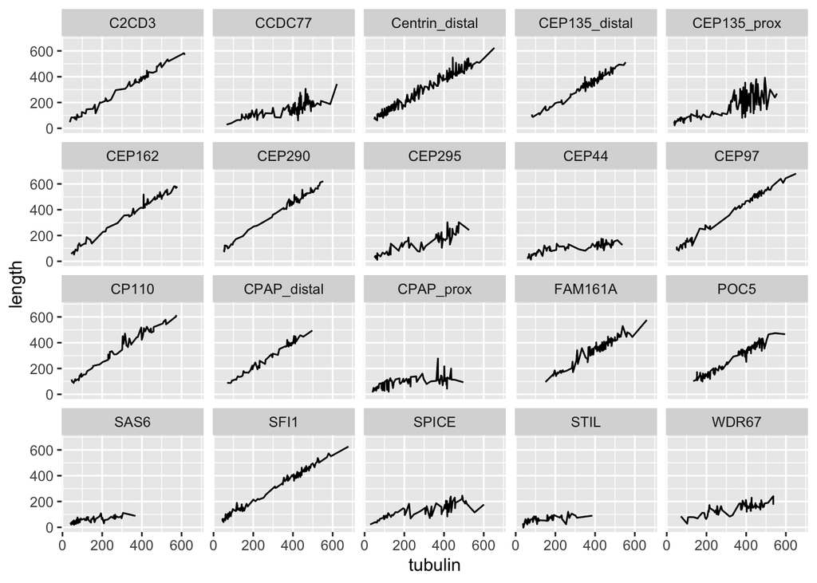

```r
library(ggplot2)
ggplot(data=growth, aes(tubulin, length)) + geom_line() +
  facet_wrap(~protein)
```

## Smoothing

To reduce the irregularities inherent to theis kind of data and facilitate comparability, we look for a smoothed version of each protein’s growth curve. For that we calculate the loess fit of each protein and then apply this fit to a grid of evenly spaced tubulin lengths.

```r
growth_by_prot <- split(growth, growth$protein)

make_loess_for_prot <- function(prot) loess(data=prot, length ~ tubulin)

growth_loess <- Map(make_loess_for_prot, growth_by_prot)

# points spaced by 10, between 30 and 600 ### maybe this needs some justification
create_tub_grid <- function(start=30, stop=600, step=10)
  data.frame(tubulin=seq(start, stop, step))
tub.grid <- create_tub_grid(stop=500)

predict_loess_for_prot.slice <- function(protfit) {
  # range m,M of tubulin lengths for current protein
  m <- min(protfit$x)
  M <- max(protfit$x)
  aux <- tub.grid[ !( tub.grid$tubulin < m | tub.grid$tubulin > M ), ]
  data.frame(tubulin=aux, length=predict(protfit, newdata=aux))
  }

predict_loess_for_prot <- predict_loess_for_prot.slice

growth_smoothed <- Map(predict_loess_for_prot, growth_loess)
```

### Graphical check

#### Current data

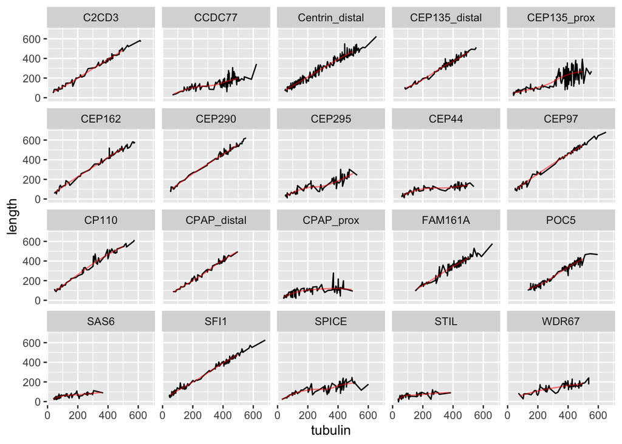

```r
growth_smoothed_df <-
  Reduce(rbind,
    Map(cbind, growth_smoothed, protein=names(growth_smoothed)))

ggplot(data=growth, aes(tubulin, length)) + geom_line() +
  geom_line(data=growth_smoothed_df, colour='red', aes(tubulin, length), alpha=0.5) +
  facet_wrap(~protein)
```

## Averaging distance

We calculate the manhattan distance between the smoothed curves of two proteins, that is, the sum of the absolute differences of their lengths on the smoothed fit at the points of the grid where both the curves are defined.

```r
str(growth_smoothed_df)
```

```
## 'data.frame':    863 obs. of  3 variables:
##  $ tubulin: num  40 50 60 70 80 90 100 110 120 130 ...
##  $ length : num  60 67.9 76 84.1 92.3 ...
##  $ protein: chr  "C2CD3" "C2CD3" "C2CD3" "C2CD3" ...
```

```r
summary(growth_smoothed_df)
```

```
##     tubulin          length         protein
##  Min.   : 30.0   Min.   : 23.18   Length:863
##  1st Qu.:170.0   1st Qu.:110.90   Class :character
##  Median :280.0   Median :169.77   Mode  :character
##  Mean   :275.8   Mean   :213.93
##  3rd Qu.:380.0   3rd Qu.:315.02
##  Max.   :500.0   Max.   :554.43
```

```r
prot_lengths_wide <- reshape2::dcast(growth_smoothed_df,  protein ~  tubulin, value.var='length')
# growth_smoothed_df[duplicated(growth_smoothed_df),]   ### this is ok now
summary(prot_lengths_wide)
```

```
##    protein                30              40              50
##  Length:20          Min.   :23.18   Min.   :24.04   Min.   :34.43
##  Class :character   1st Qu.:23.18   1st Qu.:28.75   1st Qu.:40.29
##  Mode  :character   Median :23.18   Median :32.84   Median :60.17
##                     Mean   :23.18   Mean   :37.95   Mean   :58.04
##                     3rd Qu.:23.18   3rd Qu.:46.15   3rd Qu.:68.13
##                     Max.   :23.18   Max.   :60.03   Max.   :95.10
##                     NA's   :19      NA's   :14      NA's   :10
##        60               70               80               90
##  Min.   : 36.09   Min.   : 35.69   Min.   : 42.08   Min.   : 48.27
##  1st Qu.: 47.85   1st Qu.: 51.43   1st Qu.: 58.52   1st Qu.: 62.51
##  Median : 75.95   Median : 71.23   Median : 62.57   Median : 85.00
##  Mean   : 69.48   Mean   : 73.09   Mean   : 79.72   Mean   : 88.02
##  3rd Qu.: 86.17   3rd Qu.: 91.85   3rd Qu.:101.94   3rd Qu.:110.19
##  Max.   :105.83   Max.   :116.58   Max.   :127.39   Max.   :138.27
##  NA's   :7        NA's   :4        NA's   :3        NA's   :2
##       100              110              120              130
##  Min.   : 54.27   Min.   : 60.05   Min.   : 62.85   Min.   : 63.98
##  1st Qu.: 66.45   1st Qu.: 71.70   1st Qu.: 75.26   1st Qu.: 78.91
##  Median : 91.72   Median : 97.99   Median :104.16   Median :110.27
##  Mean   : 95.23   Mean   :102.19   Mean   :109.02   Mean   :115.80
##  3rd Qu.:119.04   3rd Qu.:127.91   3rd Qu.:136.79   3rd Qu.:145.70
##  Max.   :149.18   Max.   :160.12   Max.   :171.15   Max.   :182.29
##  NA's   :2        NA's   :2        NA's   :2        NA's   :2
##       140              150              160              170
##  Min.   : 64.95   Min.   : 66.20   Min.   : 67.09   Min.   : 67.60
##  1st Qu.: 83.24   1st Qu.: 87.47   1st Qu.: 92.04   1st Qu.: 95.83
##  Median :120.30   Median :124.17   Median :122.50   Median :129.16
##  Mean   :122.37   Mean   :128.80   Mean   :134.19   Mean   :140.54
##  3rd Qu.:152.23   3rd Qu.:161.10   3rd Qu.:167.39   3rd Qu.:176.04
##  Max.   :193.52   Max.   :204.80   Max.   :216.13   Max.   :227.48
##  NA's   :1        NA's   :1
##       180              190              200              210
##  Min.   : 67.99   Min.   : 68.55   Min.   : 69.53   Min.   : 70.77
##  1st Qu.: 99.45   1st Qu.:102.47   1st Qu.:104.98   1st Qu.:108.13
##  Median :136.12   Median :143.36   Median :150.89   Median :158.70
##  Mean   :146.86   Mean   :153.18   Mean   :159.52   Mean   :165.86
##  3rd Qu.:184.68   3rd Qu.:193.85   3rd Qu.:203.06   3rd Qu.:212.39
##  Max.   :238.82   Max.   :250.15   Max.   :261.42   Max.   :272.63
##
```

[output cut: 49 more lines]

```
##  Min.   :113.9   Min.   :112.4   Min.   :110.8   Min.   :109.1
##  1st Qu.:193.1   1st Qu.:198.3   1st Qu.:203.7   1st Qu.:209.3
##  Median :410.0   Median :419.1   Median :428.5   Median :438.1
##  Mean   :349.9   Mean   :356.4   Mean   :362.9   Mean   :369.4
##  3rd Qu.:460.1   3rd Qu.:468.9   3rd Qu.:477.5   3rd Qu.:486.0
##  Max.   :516.3   Max.   :524.4   Max.   :534.1   Max.   :544.2
##  NA's   :2       NA's   :2       NA's   :2       NA's   :2
##       500
##  Min.   :141.3
##  1st Qu.:245.6
##  Median :447.3
##  Mean   :384.9
##  3rd Qu.:491.0
##  Max.   :554.4
##  NA's   :4
```

```r
prot_dists <- {
  aux <- dist(prot_lengths_wide, method='manha')
  aux <- as.matrix(aux)
  dimnames(aux) <- list(prot_lengths_wide$protein, prot_lengths_wide$protein)
  as.dist(aux)
}
```

A visual check using NMDS (preserves local distance structure better than PCA)

```
## Initial stress        : 0.00926
## stress after  10 iters: 0.00144, magic = 0.500
## stress after  20 iters: 0.00134, magic = 0.500
```

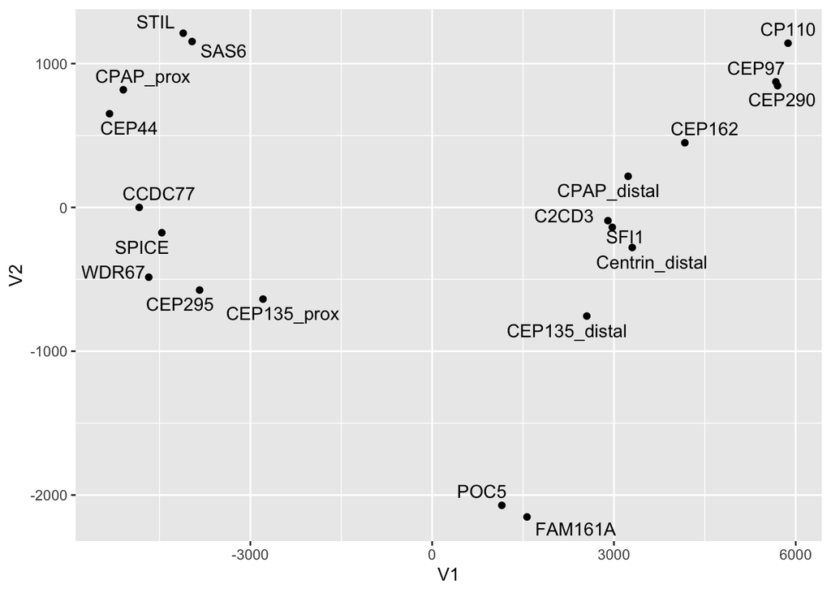

```r
library(ggfortify)
autoplot(MASS::sammon(prot_dists), label=TRUE, label.repel=TRUE)
```

## Normalisation

The distances as calculated above make a proportional resizing for the independent (tubulin grid) lengths not present. According to the R documentation: > … If some columns are excluded in calculating a Euclidean, Manhattan, Canberra or Minkowski distance, the sum is scaled up proportionally to the number of columns used. If all pairs are excluded when calculating a particular distance, the value is NA.

This affects distances because some proteins are not present all along the tubulin grid lengths. Some normalisation seems required. In order to normalise the values we need the get start and stop points for each protein, and protein pairs thereof. The average the manhattan distances over the common tubulin range. #### curr data

```r
prot_limits <- {
  x0 <- aggregate(data=growth_smoothed_df, tubulin ~ protein, \(x) c(min(x), max(x)))
  x1 <- data.frame(protein=x0[[1]], min=x0[[2]][,1], max=x0[[2]][,2])
  x1
  }

prot_pairs_limits <- {
  x0 <- expand.grid(prot_limits$protein, prot_limits$protein, stringsAsFactors=FALSE)
  x0 <- x0[x0$Var1 >= x0$Var2,]
  get_prot_pairs_limits <- function(x,y) {
    x1 <- prot_limits[prot_limits$protein %in% c(x,y),]
    data.frame(Var1=x, Var2=y, min=max(x1$min), max=min(x1$max))
  }
  Reduce(rbind, Map(get_prot_pairs_limits, x0$Var1, x0$Var2))
}

prot_pairs_dists <- {
  pair_dist <- function(x, y, m, M) {
    if (x == y) return(0)
    x0 <- growth_smoothed_df
    x0 <- x0[x0$protein %in% c(x, y) & x0$tubulin >= m & x0$tubulin <= M, ]
    x1 <- aggregate(data=x0, length ~ tubulin, \(x) abs(diff(x)))
    sum(x1$length) / (M-m)
  }
  cbind(
    prot_pairs_limits,
    dist=unlist(Map(pair_dist, prot_pairs_limits$Var1, prot_pairs_limits$Var2, prot_pairs_limits$min, prot_pairs_limits$max))
  )
}
prot_dists_norm <- as.dist(t(as.matrix.data.frame(reshape2::dcast(data=prot_pairs_dists, Var2 ~ Var1, value.var='dist')[,-1])))
```

## Cluster analysis

### How many clusters to use?

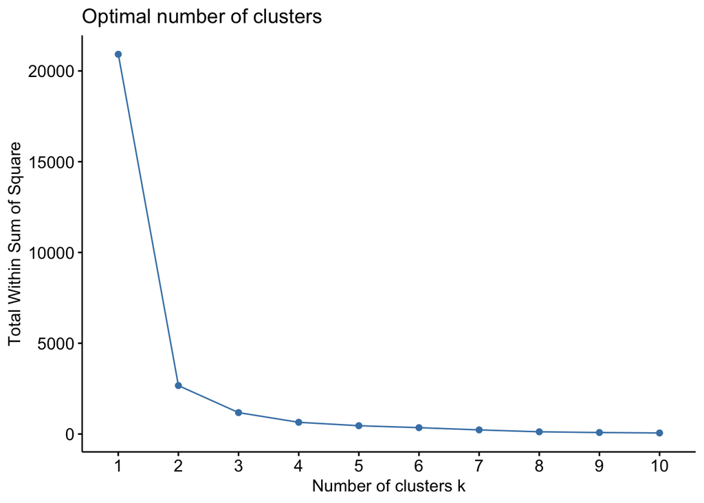

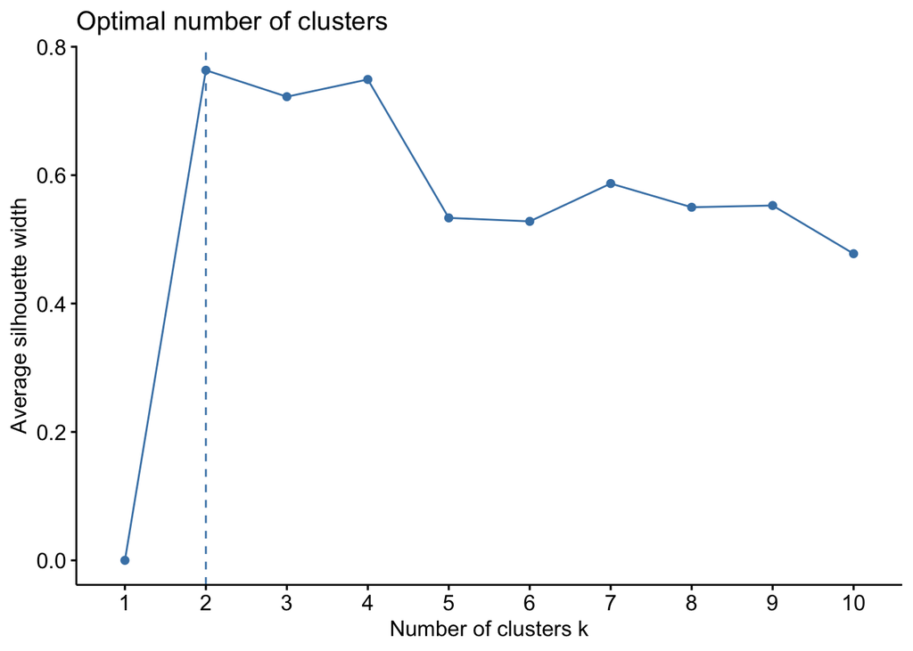

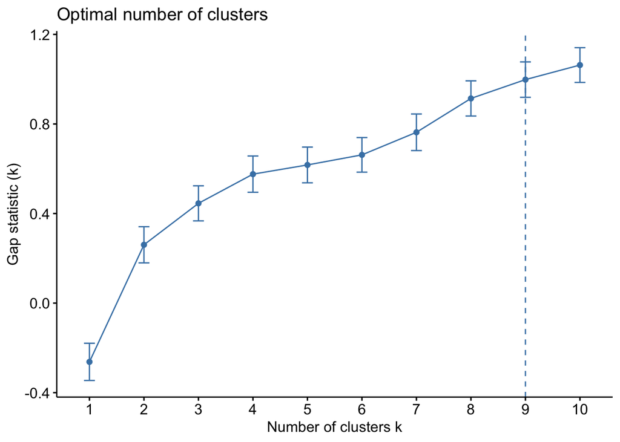

```r
library(cluster)
library(factoextra)
prot_dists_df <- as.matrix(prot_dists_norm)
#rownames(prot_dists_df) <-
#  rownames(prot_dists_df) <- levels(growth$protein)
fviz_nbclust(prot_dists_df, pam, 'wss')
fviz_nbclust(prot_dists_df, pam, 'silhouette')
fviz_nbclust(prot_dists_df, pam, 'gap_stat')
```

Combining the results above it seems reasonable to go with 2 or 7 clusters. We’ll look at the representations for a final decision.

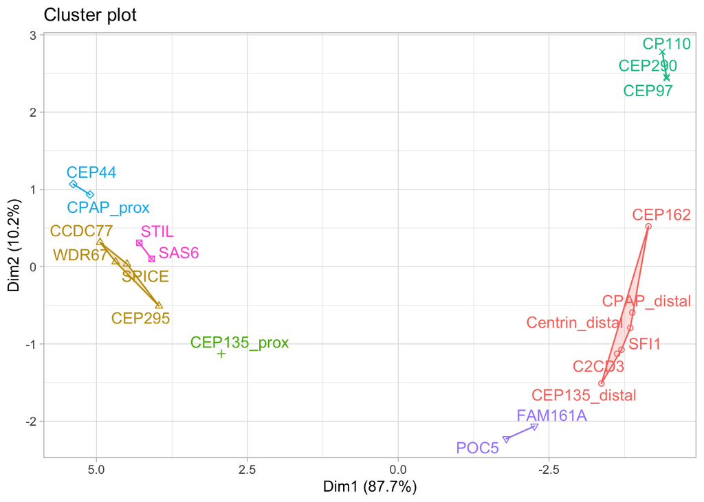

```r
fviz_cluster(pam(prot_dists_df,7), repel=TRUE) +
  scale_x_reverse() +
#  coord_fixed() +
  theme_light() +
  guides(fill='none', shape='none', colour='none')
```